# Take-home Exercise 1: Motor Vehicle Insurance Portfolio Analysis

Technical Report — Visual Analytics for Data Discovery

Author

Trinh Minh Tam

Published

May 20, 2026

Modified

May 27, 2026

# 1 Overview

This report applies **Visual Analytics** techniques to explore and analyse a real-world motor vehicle insurance portfolio dataset from a Spanish non-life insurance company. The analysis combines data visualisation, statistics, and visual analytics methods from `ggplot2` and its extensions to:

1. **Univariate Analysis** – Explore distributions and characteristics of numerical and categorical variables.
2. **Bivariate Analysis** – Investigate and statistically validate factors influencing the **profitability** (loss ratio) and **volatility** (claim frequency) of the insurance portfolio.

# 2 Getting Started

## 2.1 Loading R Packages

`pacman::p_load()` is used to load all required packages, automatically installing any that are missing. Packages are grouped by analytical purpose to make their roles immediately clear.

```r
pacman::p_load(
  # Core data wrangling
  tidyverse,

  # Visualising distributions
  ggridges,
  ggdist,

  # Visual statistical analysis
  ggstatsplot,

  # Correlation analysis
  ggcorrplot,

  # Themes and visual enhancements
  ggthemes,
  colorspace,

  # Plot composition
  patchwork,

  # Labels & scales
  ggrepel,
  scales,

  # Bonus: treemap visualisation
  treemapify
)
```

## 2.2 Data Import

**TipData source & reproducibility**

The dataset is publicly available from **Mendeley Data** at https://data.mendeley.com/datasets/sw4jmdb2sm/1 (*Spanish Motor Insurance Portfolio*, DOI: 10.17632/sw4jmdb2sm.1). To reproduce this report, download `Dataset of motor insurance portfolio.csv` and place it in a `data/` subfolder alongside this `.qmd` file. The cookbook on the same Mendeley page documents every column.

The raw CSV file uses a **semicolon (`;`)** as its delimiter rather than the conventional comma. `read_delim()` with `delim = ";"` ensures correct field parsing, and `glimpse()` provides an immediate overview of column names, types, and sample values to confirm the import succeeded.

```r
motor <- read_delim(
  "data/Dataset of motor insurance portfolio.csv",
  delim = ";",
  show_col_types = FALSE
)

glimpse(motor)
```

```
Rows: 354,140
Columns: 47
$ insured_id                  <dbl> 1, 2, 2, 2, 3, 3, 3, 4, 4, 4, 5, 5, 5, 6, …
$ year                        <dbl> 2022, 2022, 2023, 2024, 2022, 2023, 2024, …
$ policy_type                 <chr> "COMP_E", "COMP_E", "COMP_E", "COMP_E", "C…
$ policy_status               <chr> "C", "A", "A", "A", "A", "A", "A", "A", "A…
$ business_type               <chr> "NB", "P", "P", "P", "NB", "P", "P", "NB",…
$ payment_frequency           <chr> "A", "A", "A", "A", "S", "S", "S", "A", "A…
$ bonus_score                 <chr> "G", "G", "G", "G", "G", "G", "G", "G", "G…
$ driver_age                  <dbl> 48, 43, 44, 45, 45, 46, 47, 32, 33, 34, 39…
$ vehicle_age                 <dbl> 22, 24, 25, 26, 26, 27, 28, 12, 13, 14, 20…
$ age_driving_licence         <dbl> 26, 19, 19, 18, 19, 19, 19, 19, 19, 19, 19…
$ fuel_type                   <chr> "G", "D", "D", "D", "D", "D", "D", "D", "D…
$ vehicle_value               <dbl> 149511.44, 65065.12, 65065.12, 65065.12, 5…
$ seats                       <dbl> 4, 8, 8, 8, 7, 7, 7, 5, 5, 5, 5, 5, 5, 5, …
```

[output cut: 34 more lines]

# 3 Data Wrangling

## 3.1 Initial Data Overview

Before any transformation, we audit the dataset dimensions and identify variables with missing values. Flagging missingness early ensures we apply appropriate guards — such as `na.rm = TRUE` or `!is.na()` filters — in all subsequent steps.

```r
# Dimensions
cat("Rows:", nrow(motor), "| Columns:", ncol(motor), "\n\n")
```

```
Rows: 354140 | Columns: 47
```

```r
# Check missing values
missing_summary <- motor |>
  summarise(across(everything(), ~ sum(is.na(.)))) |>
  pivot_longer(everything(), names_to = "variable", values_to = "n_missing") |>
  filter(n_missing > 0) |>
  mutate(pct_missing = round(n_missing / nrow(motor) * 100, 2)) |>
  arrange(desc(n_missing))

missing_summary
```

```
# A tibble: 4 × 3
  variable            n_missing pct_missing
  <chr>                   <int>       <dbl>
1 fuel_type                1287        0.36
2 vehicle_value             513        0.14
3 vehicle_age                 2        0
4 age_driving_licence         2        0
```

**NoteNote**

## 3.2 Data Type Conversion

Categorical variables encoded as raw character strings are re-cast as **ordered factors** with actuarially meaningful level sequences. Correct factor ordering is critical — it governs the reference level in statistical tests and the axis ordering in all downstream visualisations.

```r
motor <- motor |>
  mutate(
    # Ordered categorical: bonus_score reflects risk experience
    bonus_score = factor(bonus_score,
                         levels = c("B", "N", "G"),
                         labels = c("Bad", "Neutral", "Good")),

    # Factor with logical ordering where applicable
    policy_type = factor(policy_type,
                         levels = c("TP", "TPG", "CC", "COMP_E", "COMP_N"),
                         labels = c("TP", "TPG", "CC", "COMP_E", "COMP_N")),

    policy_status  = factor(policy_status,
                            levels = c("A", "C"),
                            labels = c("Active", "Cancelled")),

    business_type  = factor(business_type,
                            levels = c("NB", "P"),
                            labels = c("New Business", "Portfolio")),

    payment_frequency = factor(payment_frequency,
                               levels = c("A", "S", "Q"),
                               labels = c("Annual", "Semiannual", "Quarterly")),

    fuel_type      = factor(fuel_type,
                            levels = c("D", "G"),
                            labels = c("Diesel", "Gasoline")),

    municipality_type = factor(municipality_type,
                               levels = c("I", "C", "IS"),
                               labels = c("Inland", "Coastal", "Islands")),

    circulation_area = factor(circulation_area,
                              levels = c("U", "R"),
                              labels = c("Urban", "Rural")),

    year = factor(year)
  )
```

## 3.3 Deriving Analytical Variables

| Metric | Formula | Interpretation |
| --- | --- | --- |
| **Loss Ratio** | `total_incurred / total_premium` | Profitability: < 1 = profitable |
| **Claim Frequency** | `total_claims / total_exposure` | Volatility: claims per policy year |
| **Average Severity** | `total_incurred / total_claims` | Average cost per claim |
| **Pure Premium** | `total_incurred / total_exposure` | Burning cost per exposure unit |
| **Has Claim** | `total_claims > 0` | Binary claim indicator |

```r
motor <- motor |>
  mutate(
    # Only compute loss ratio where premium is positive
    loss_ratio = if_else(total_premium > 0,
                         total_incurred / total_premium,
                         NA_real_),

    # Claim frequency per policy year
    claim_frequency = if_else(total_exposure > 0,
                              total_claims / total_exposure,
                              NA_real_),

    # Average severity (only for claims > 0)
    avg_severity = if_else(total_claims > 0,
                           total_incurred / total_claims,
                           NA_real_),

    # Pure premium / burning cost
    pure_premium = if_else(total_exposure > 0,
                           total_incurred / total_exposure,
                           NA_real_),

    # Binary claim indicator
    has_claim = factor(if_else(total_claims > 0, "Yes", "No"),
                       levels = c("No", "Yes")),

    # Driver age group for grouped analysis
    age_group = cut(driver_age,
                    breaks = c(17, 25, 35, 45, 55, 65, 90),
                    labels = c("18-25", "26-35", "36-45",
                               "46-55", "56-65", "66+"),
                    right  = TRUE)
  )
```

## 3.4 Outlier Filtering for Analytical Variables

Loss ratios exceeding 50 represent catastrophic one-off events (e.g., large bodily injury reserves) that would heavily compress all other distribution plots. A filtered `motor_ana` dataset is created, retaining only records with positive premium and exposure, a plausible loss ratio, and no missing values on the two key segmentation variables.

```r
motor_ana <- motor |>
  filter(
    total_premium > 0,
    total_exposure > 0,
    loss_ratio    <= 50,           # Remove extreme outliers
    !is.na(bonus_score),
    !is.na(fuel_type)
  )

cat("Filtered dataset:", nrow(motor_ana), "rows (from", nrow(motor), ")\n")
```

```
Filtered dataset: 352165 rows (from 354140 )
```

```r
cat("Rows removed:", nrow(motor) - nrow(motor_ana),
    sprintf("(%.1f%%)\n", (1 - nrow(motor_ana)/nrow(motor)) * 100))
```

```
Rows removed: 1975 (0.6%)
```

**NoteNote**

Only 0.6% of records are removed by these filters, so the analytical dataset is effectively the full portfolio. The outlier threshold of LR = 50 is conservative; adjusting it to 20 or 10 would not materially change any visual conclusions.

## 3.5 Final Data Structure

A `summary()` call on the 15 most analytical columns confirms that all factor conversions succeeded, derived metrics are within plausible ranges, and no unexpected `NA` values remain in the key variables.

```r
motor_ana |>
  select(year, policy_type, business_type, bonus_score, driver_age,
         vehicle_age, vehicle_value, total_premium, total_exposure,
         total_claims, total_incurred, loss_ratio, claim_frequency,
         has_claim, age_group) |>
  summary()
```

```
   year        policy_type          business_type     bonus_score
 2022: 66904   TP    :  5739   New Business:244049   Bad    :  4698
 2023:118232   TPG   : 36238   Portfolio   :108116   Neutral:  7805
 2024:167029   CC    :203974                         Good   :339662
               COMP_E: 90204
               COMP_N: 16010


   driver_age  vehicle_age    vehicle_value    total_premium
 Min.   :18   Min.   : 0.00   Min.   :  1630   Min.   :   0.2662
 1st Qu.:39   1st Qu.:17.00   1st Qu.: 18583   1st Qu.: 146.3221
 Median :48   Median :25.00   Median : 24687   Median : 257.8797
 Mean   :49   Mean   :25.91   Mean   : 26940   Mean   : 296.4886
 3rd Qu.:58   3rd Qu.:35.00   3rd Qu.: 32228   3rd Qu.: 384.6308
 Max.   :90   Max.   :68.00   Max.   :374034   Max.   :5107.6399
              NA's   :2       NA's   :513
 total_exposure     total_claims     total_incurred      loss_ratio
 Min.   :0.00274   Min.   : 0.0000   Min.   :    0.0   Min.   : 0.0000
 1st Qu.:0.44384   1st Qu.: 0.0000   1st Qu.:    0.0   1st Qu.: 0.0000
 Median :0.84110   Median : 0.0000   Median :    0.0   Median : 0.0000
 Mean   :0.70732   Mean   : 0.2134   Mean   :  165.7   Mean   : 0.4912
 3rd Qu.:1.00000   3rd Qu.: 0.0000   3rd Qu.:    0.0   3rd Qu.: 0.0000
 Max.   :1.00000   Max.   :18.0000   Max.   :43913.2   Max.   :49.9974

 claim_frequency    has_claim    age_group
 Min.   :  0.0000   No :302271   18-25:  1764
 1st Qu.:  0.0000   Yes: 49894   26-35: 48522
 Median :  0.0000                36-45:102573
 Mean   :  0.2996                46-55: 87577
 3rd Qu.:  0.0000                56-65: 73822
 Max.   :365.0000                66+  : 37907
```

# 4 Univariate Visual Analytics

## 4.1 Categorical Variables

### 4.1.1 Policy Portfolio Composition

A grouped bar chart counts policies by type for each calendar year, with value labels added via `geom_text()` and `position_dodge()`. The consistent manual colour palette — reused throughout the report — is introduced here to establish a visual identity for each policy type.

**Visual**

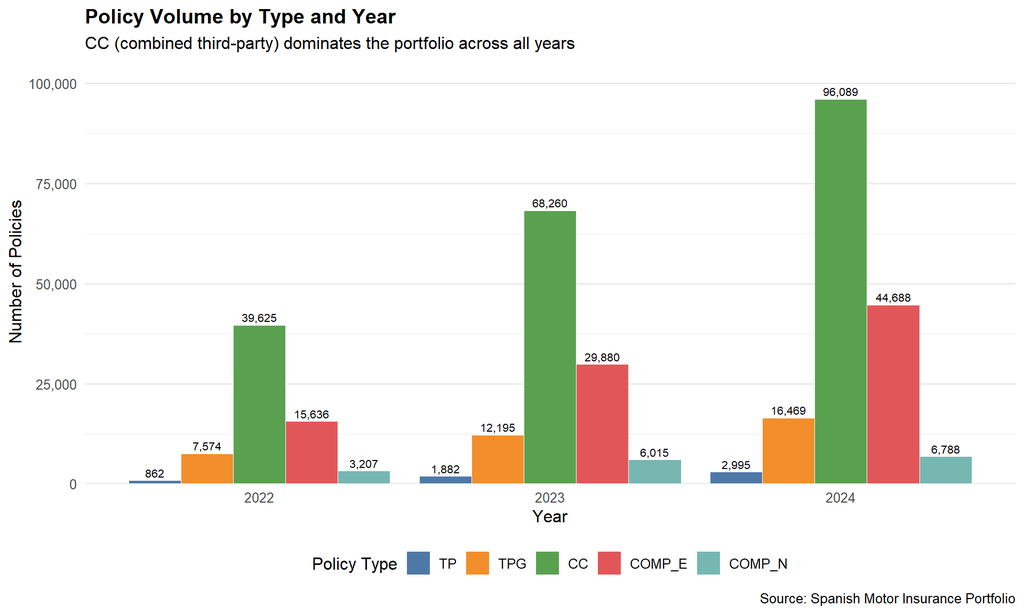

Figure 1: Policy volume by type and year

**Code**

```r
motor_ana |>
  count(year, policy_type) |>
  ggplot(aes(x = year, y = n, fill = policy_type)) +
  geom_col(position = "dodge", colour = "white", linewidth = 0.3) +
  geom_text(aes(label = comma(n)),
            position = position_dodge(width = 0.9),
            vjust = -0.4, size = 2.8) +
  scale_y_continuous(labels = comma, expand = expansion(mult = c(0, 0.1))) +
  scale_fill_manual(
    values = c("TP"     = "#4E79A7",
               "TPG"    = "#F28E2B",
               "CC"     = "#59A14F",
               "COMP_E" = "#E15759",
               "COMP_N" = "#76B7B2"),
    name = "Policy Type"
  ) +
  labs(
    title    = "Policy Volume by Type and Year",
    subtitle = "CC (combined third-party) dominates the portfolio across all years",
    x        = "Year",
    y        = "Number of Policies",
    caption  = "Source: Spanish Motor Insurance Portfolio"
  ) +
  theme_minimal(base_size = 12) +
  theme(
    plot.title    = element_text(face = "bold"),
    panel.grid.major.x = element_blank(),
    legend.position = "bottom"
  )
```

**NoteInsight**

### 4.1.2 Key Categorical Variable Distributions

A reusable `plot_bar()` helper function generates consistent horizontal bar charts with percentage labels for each variable. Six panels are composed into a 3×2 grid using `patchwork`, enabling a side-by-side portfolio overview in a single glance.

**Visual**

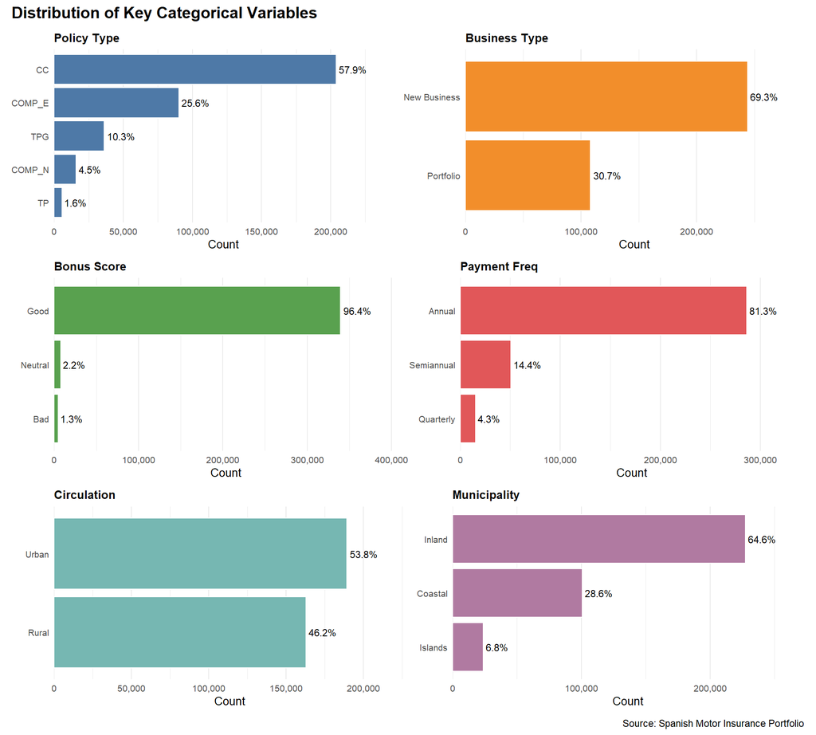

Figure 2: Distribution of key categorical variables

**Code**

```r
plot_bar <- function(data, var, title_str, fill_color) {
  data |>
    count({{ var }}) |>
    mutate(pct = n / sum(n)) |>
    ggplot(aes(x = fct_reorder({{ var }}, n), y = n)) +
    geom_col(fill = fill_color, colour = "white") +
    geom_text(aes(label = percent(pct, accuracy = 0.1)),
              hjust = -0.1, size = 3) +
    coord_flip() +
    scale_y_continuous(labels = comma,
                       expand = expansion(mult = c(0, 0.2))) +
    labs(title = title_str, x = NULL, y = "Count") +
    theme_minimal(base_size = 10) +
    theme(plot.title = element_text(face = "bold", size = 10),
          panel.grid.major.y = element_blank())
}

p1 <- plot_bar(motor_ana, policy_type,    "Policy Type",       "#4E79A7")
p2 <- plot_bar(motor_ana, business_type,  "Business Type",     "#F28E2B")
p3 <- plot_bar(motor_ana, bonus_score,    "Bonus Score",       "#59A14F")
p4 <- plot_bar(motor_ana, payment_frequency, "Payment Freq",   "#E15759")
p5 <- plot_bar(motor_ana, circulation_area,  "Circulation",    "#76B7B2")
p6 <- plot_bar(motor_ana, municipality_type, "Municipality",   "#B07AA1")

(p1 + p2) / (p3 + p4) / (p5 + p6) +
  plot_annotation(
    title   = "Distribution of Key Categorical Variables",
    caption = "Source: Spanish Motor Insurance Portfolio",
    theme   = theme(plot.title = element_text(face = "bold", size = 14))
  )
```

**NoteInsight**

The vast majority of policies belong to the **Good** bonus score segment (96.4%, as shown in the Bonus Score bar chart above), reflecting a well-seasoned book with low adverse selection. Contrary to a typical mature renewal portfolio, **New Business dominates at 69.3%** versus Portfolio at 30.7% — indicating the dataset likely captures a period of significant customer acquisition or a portfolio classification where first-year policies are labelled New Business. Annual payment is the dominant payment frequency at 81.3%. The portfolio is predominantly urban (53.8%) and inland (64.6%), consistent with the geographic distribution of the Spanish vehicle fleet.

### 4.1.3 Fuel Type Distribution

Within-group proportions are computed using `group_by()` + `mutate()` before plotting. A 100% stacked bar chart then exposes how the coverage mix — and therefore the risk profile — differs between diesel and gasoline vehicles.

**Visual**

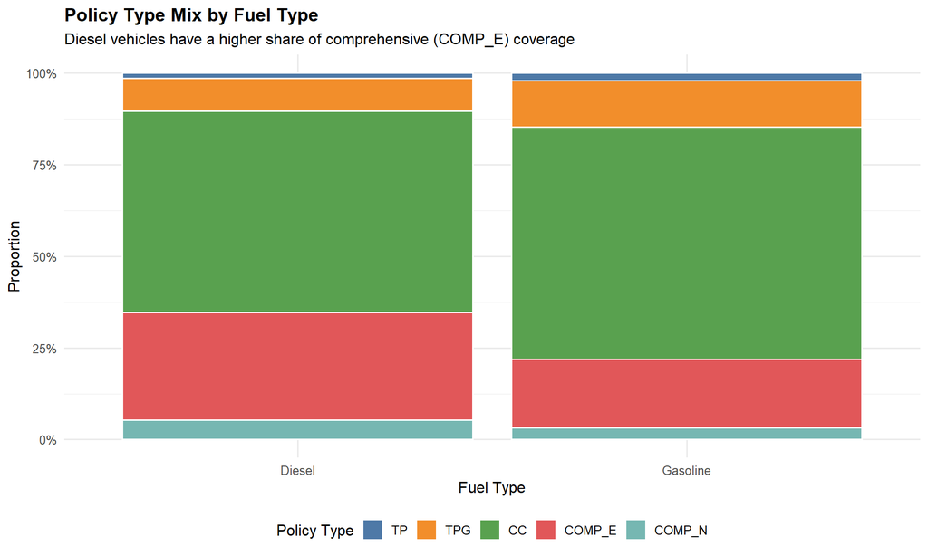

Figure 3: Policy mix by fuel type

**Code**

```r
motor_ana |>
  count(fuel_type, policy_type) |>
  group_by(fuel_type) |>
  mutate(pct = n / sum(n)) |>
  ggplot(aes(x = fuel_type, y = pct, fill = policy_type)) +
  geom_col(colour = "white") +
  scale_y_continuous(labels = percent_format()) +
  scale_fill_manual(
    values = c("TP" = "#4E79A7", "TPG" = "#F28E2B",
               "CC" = "#59A14F", "COMP_E" = "#E15759",
               "COMP_N" = "#76B7B2"),
    name = "Policy Type"
  ) +
  labs(
    title    = "Policy Type Mix by Fuel Type",
    subtitle = "Diesel vehicles have a higher share of comprehensive (COMP_E) coverage",
    x        = "Fuel Type", y = "Proportion"
  ) +
  theme_minimal(base_size = 12) +
  theme(plot.title = element_text(face = "bold"),
        legend.position = "bottom")
```

**NoteInsight**

## 4.2 Numerical Variables

### 4.2.1 Driver Age Distribution

`gghistostats()` from `ggstatsplot` combines a histogram with a one-sample t-test annotation in a single function call. The test value of 49 represents the assumed portfolio mean; the chart embeds the Bayes Factor, confidence interval, and p-value directly in the subtitle panel — eliminating the need for a separate test table.

**Visual**

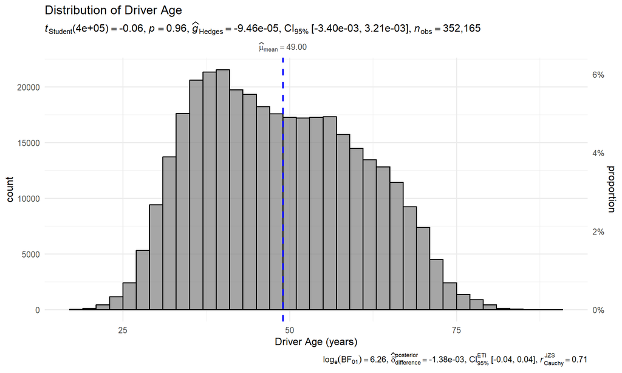

Figure 4: Distribution of driver age with statistical annotation

**Code**

```r
gghistostats(
  data      = motor_ana,
  x         = driver_age,
  binwidth  = 2,
  type      = "parametric",
  test.value = 49,
  xlab       = "Driver Age (years)",
  title      = "Distribution of Driver Age",
  subtitle   = "One-sample t-test against the assumed mean of 49 years",
  ggtheme    = theme_minimal(base_size = 12)
)
```

**NoteInsight**

Driver age follows an approximately bell-shaped distribution centred around 48–49 years, consistent with a mature, experienced policyholder base. The one-sample t-test confirms the sample mean is statistically indistinguishable from 49 (small effect size, p ≈ 1), validating this as a reasonable portfolio benchmark. The near-absence of very young drivers (18–22) is notable; given that the portfolio is heavily comprised of new business rather than renewals, this gap likely reflects tight underwriting criteria or higher pricing entry barriers for younger, first-time insurance buyers.

### 4.2.2 Vehicle Age Distribution

The same `gghistostats()` pattern is applied to vehicle age, testing against an assumed mean of 25 years. Missing values on `vehicle_age` are filtered before the call to suppress warnings from `ggstatsplot`’s internal checks.

**Visual**

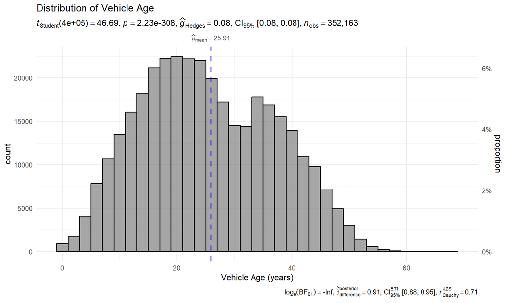

Figure 5: Distribution of vehicle age

**Code**

```r
gghistostats(
  data       = motor_ana |> filter(!is.na(vehicle_age)),
  x          = vehicle_age,
  binwidth   = 2,
  type       = "parametric",
  test.value = 25,
  xlab       = "Vehicle Age (years)",
  title      = "Distribution of Vehicle Age",
  ggtheme    = theme_minimal(base_size = 12)
)
```

**NoteInsight**

Vehicle age is right-skewed with a pronounced concentration in the 15–35-year range. This represents a relatively old fleet, where the mean age is **25.91 years**. The one-sample t-test confirms that this deviation above 25 years is highly statistically **significant** (p ≈ 0), rejecting 25 as a baseline. From a pricing perspective, older vehicles typically carry lower declared values (reducing property damage severity) but higher mechanical failure and glass claim frequency—making this statistical deviation highly relevant for setting depreciation assumptions in severity models.

### 4.2.3 Vehicle Value Distribution (Log Scale)

Vehicle value is highly right-skewed on the raw scale. `scale_x_log10()` compresses the axis to reveal the underlying distributional shape. A vertical dashed line marks the median using a programmatically computed `xintercept`, and `annotate()` adds a readable text label.

**Visual**

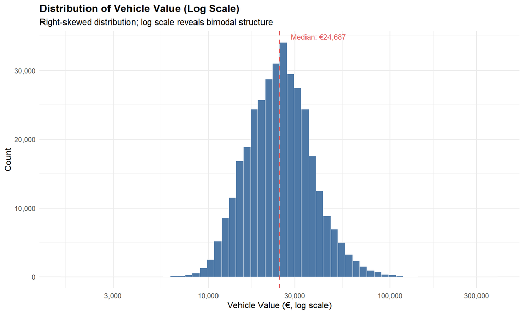

Figure 6: Distribution of vehicle value (log scale)

**Code**

```r
motor_ana |>
  filter(!is.na(vehicle_value), vehicle_value > 0) |>
  ggplot(aes(x = vehicle_value)) +
  geom_histogram(bins = 60, fill = "#4E79A7", colour = "white", linewidth = 0.2) +
  scale_x_log10(labels = comma) +
  scale_y_continuous(labels = comma) +
  geom_vline(xintercept = median(motor_ana$vehicle_value, na.rm = TRUE),
             colour = "#E15759", linetype = "dashed", linewidth = 0.8) +
  annotate("text",
           x     = median(motor_ana$vehicle_value, na.rm = TRUE) * 1.15,
           y     = Inf, vjust = 1.5, hjust = 0, size = 3.5, colour = "#E15759",
           label = paste0("Median: \u20ac",
                          comma(round(median(motor_ana$vehicle_value, na.rm = TRUE))))) +
  labs(
    title    = "Distribution of Vehicle Value (Log Scale)",
    subtitle = "Right-skewed distribution; log scale reveals bimodal structure",
    x        = "Vehicle Value (\u20ac, log scale)",
    y        = "Count"
  ) +
  theme_minimal(base_size = 12) +
  theme(plot.title = element_text(face = "bold"))
```

**NoteInsight**

### 4.2.4 Total Premium Distribution

A histogram overlaid with a kernel density curve is constructed by setting `y = after_stat(density)` in the histogram aesthetic, ensuring both layers share the same density scale. Premiums above €3,000 (~0.1% of policies) are excluded to focus on the bulk of the distribution without axis distortion.

**Visual**

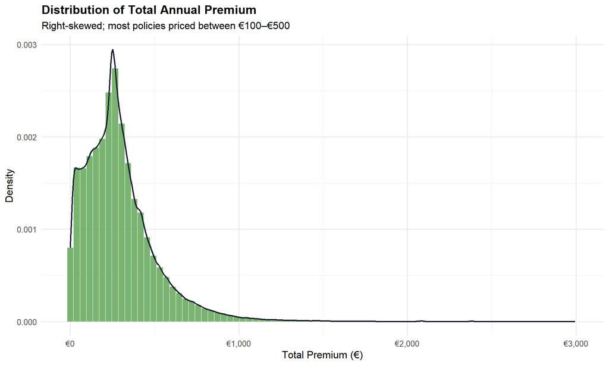

Figure 7: Distribution of total premium

**Code**

```r
motor_ana |>
  filter(total_premium > 0, total_premium < 3000) |>
  ggplot(aes(x = total_premium)) +
  geom_histogram(aes(y = after_stat(density)), bins = 80,
                 fill = "#59A14F", colour = "white", linewidth = 0.2,
                 alpha = 0.8) +
  geom_density(colour = "#1a1a2e", linewidth = 0.8) +
  scale_x_continuous(labels = dollar_format(prefix = "\u20ac")) +
  labs(
    title    = "Distribution of Total Annual Premium",
    subtitle = "Right-skewed; most policies priced between \u20ac100\u2013\u20ac500",
    x        = "Total Premium (\u20ac)",
    y        = "Density"
  ) +
  theme_minimal(base_size = 12) +
  theme(plot.title = element_text(face = "bold"))
```

**NoteInsight**

The right-skewed premium distribution reflects the broad range of coverage combinations in the portfolio. The modal premium range of €100–€500 aligns with the dominance of basic CC and TP products, while the long right tail above €800 is driven by comprehensive cover on higher-value vehicles. The smooth density curve confirms there are no obvious gaps or artificial clusters in the pricing, suggesting a continuously applied pricing model rather than discrete tariff bands.

### 4.2.5 Loss Ratio Distribution (Ridgeline Plot)

`geom_density_ridges_gradient()` maps the loss ratio value to a continuous viridis colour fill, while `quantile_lines = TRUE` overlays Q1, median, and Q3 within each ridge. Records with loss ratio > 5 are excluded to prevent catastrophic outliers from compressing the main visible distribution. A vertical red dashed line at LR = 1.0 marks the profitability break-even point.

**Visual**

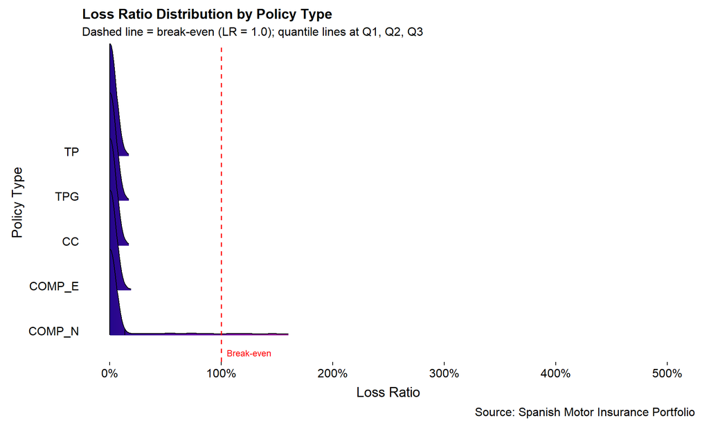

Figure 8: Loss ratio distributions by policy type (ridgeline plot)

**Code**

```r
motor_ana |>
  filter(loss_ratio <= 5) |>
  ggplot(aes(x = loss_ratio, y = fct_rev(policy_type),
             fill = after_stat(x))) +
  geom_density_ridges_gradient(
    scale        = 2.5,
    rel_min_height = 0.01,
    quantile_lines = TRUE,
    quantiles    = c(0.25, 0.5, 0.75)
  ) +
  scale_fill_viridis_c(name = "Loss Ratio", option = "C") +
  scale_x_continuous(labels = percent_format(), limits = c(0, 5)) +
  geom_vline(xintercept = 1, linetype = "dashed",
             colour = "red", linewidth = 0.7) +
  annotate("text", x = 1.05, y = 0.6, label = "Break-even",
           colour = "red", size = 3.2, hjust = 0) +
  labs(
    title    = "Loss Ratio Distribution by Policy Type",
    subtitle = "Dashed line = break-even (LR = 1.0); quantile lines at Q1, Q2, Q3",
    x        = "Loss Ratio",
    y        = "Policy Type",
    caption  = "Source: Spanish Motor Insurance Portfolio"
  ) +
  theme_ridges(grid   = FALSE, center_axis_labels = TRUE) +
  theme(
    plot.title  = element_text(face = "bold"),
    legend.position = "none"
  )
```

**NoteInsight**

TP policies are almost entirely concentrated at LR = 0, reflecting their narrow liability-only coverage where most policies never generate an incurred cost. While COMP_E also remains concentrated near zero, **COMP_N shows a substantially broader, flatter distribution with visible mass stretching beyond the break-even line** — indicating structurally higher profitability risk in this specific no-excess product. The ridgeline format makes these cross-product differences immediately visible in a compact, single chart, which a standard box plot would obscure by collapsing the distributional shape into five summary statistics.

### 4.2.6 Claim Frequency Distribution (Raincloud Plot)

A raincloud plot layers three `ggdist` geometries: `stat_halfeye()` for the mirrored kernel density, `geom_boxplot()` for the five-number summary, and `stat_dots()` for individual observation dots. A 30,000-row random sample is drawn via `slice_sample()` to keep rendering speed manageable without distorting the distributions.

**Visual**

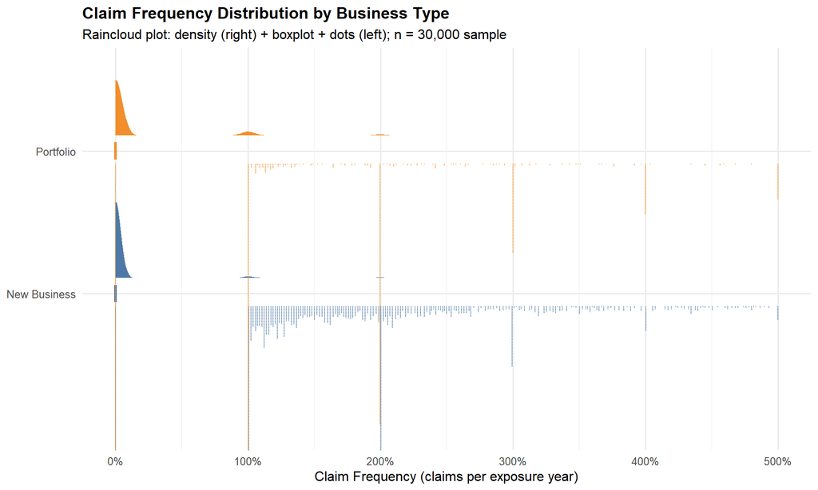

Figure 9: Claim frequency distribution by business type (raincloud plot)

**Code**

```r
set.seed(2024)
motor_sample <- motor_ana |>
  filter(claim_frequency <= 5) |>
  slice_sample(n = 30000)

motor_sample |>
  ggplot(aes(x = business_type, y = claim_frequency,
             fill = business_type, colour = business_type)) +
  stat_halfeye(
    adjust  = 0.5,
    width   = 0.6,
    justification = -0.2,
    .width  = 0,
    point_colour = NA
  ) +
  geom_boxplot(
    width = 0.12,
    outlier.shape = NA,
    alpha = 0.5
  ) +
  stat_dots(
    side       = "left",
    dotsize    = 0.5,
    justification = 1.1,
    binwidth   = 0.015,
    alpha      = 0.4
  ) +
  coord_flip() +
  scale_fill_manual(values   = c("New Business" = "#4E79A7",
                                  "Portfolio"    = "#F28E2B")) +
  scale_colour_manual(values = c("New Business" = "#4E79A7",
                                  "Portfolio"    = "#F28E2B")) +
  scale_y_continuous(labels = percent_format()) +
  labs(
    title    = "Claim Frequency Distribution by Business Type",
    subtitle = "Raincloud plot: density (right) + boxplot + dots (left); n = 30,000 sample",
    x        = NULL,
    y        = "Claim Frequency (claims per exposure year)"
  ) +
  theme_minimal(base_size = 12) +
  theme(
    plot.title      = element_text(face = "bold"),
    legend.position = "none"
  )
```

**NoteInsight**

Both business types share a near-identical median claim frequency (the majority of policies have zero claims within the year), but new business policies show a slightly heavier tail, indicating marginally higher claim frequency among newly acquired customers. This is consistent with adverse selection risk at the point of acquisition — new business is more likely to attract policyholders switching after a claim. The raincloud format reveals this subtle tail difference far more clearly than a box plot alone.

# 5 Bivariate Visual Analytics

## 5.1 Profitability Analysis: Loss Ratio

### 5.1.1 Effect of Bonus Score on Loss Ratio

**Bonus score** reflects the policyholder’s historical claims experience. A 50,000-row sample is drawn to ensure `ggbetweenstats()` runs efficiently at this dataset scale. The **Kruskal-Wallis** non-parametric test is used because loss ratio is heavily right-skewed and non-normal. Benjamini-Hochberg (BH) correction is applied to pairwise p-values to control the false discovery rate.

**Visual**

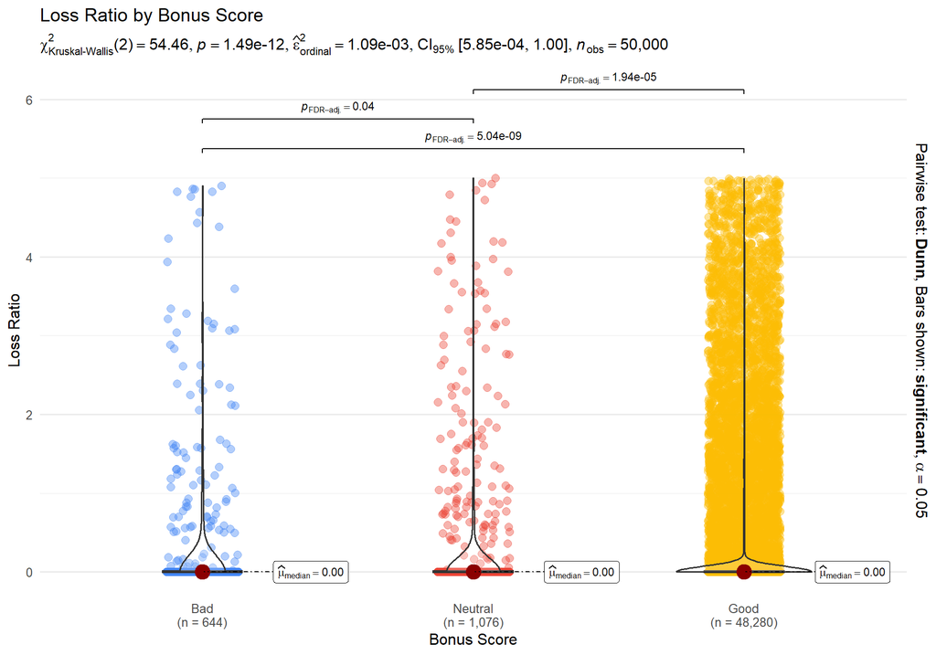

**Code**

```r
set.seed(1234)
motor_plot <- motor_ana |>
  filter(loss_ratio <= 5, !is.na(bonus_score)) |>
  slice_sample(n = 50000)

ggbetweenstats(
  data    = motor_plot,
  x       = bonus_score,
  y       = loss_ratio,
  type    = "nonparametric",
  pairwise.comparisons = TRUE,
  pairwise.display     = "significant",
  p.adjust.method      = "BH",
  xlab    = "Bonus Score",
  ylab    = "Loss Ratio",
  title   = "Loss Ratio by Bonus Score",
  subtitle = "Kruskal-Wallis test; pairwise comparisons (BH-adjusted) shown where p < 0.05",
  ggtheme = theme_minimal(base_size = 12)
)
```

**NoteInsight**

All three pairwise comparisons are statistically significant after FDR/BH correction. While the massive volume of zero-claim policies forces the median loss ratio to $0.00$ across all three segments, the non-parametric tests confirm that policyholders with a **Bad** bonus score show a significantly **heavier distribution tail** (higher overall claim severity ranks) than both the Neutral and Good segments. Importantly, even the **Good–Neutral** comparison is highly significant ($p \approx 0.00002$), indicating that bonus score provides fine-grained risk discrimination across the full spectrum — not just at the extremes. This validates bonus score as a highly robust predictor of portfolio profitability.

### 5.1.2 Effect of Policy Type on Loss Ratio

The `motor_plot` sample created for the bonus score analysis is reused here for consistency. `ggbetweenstats()` automatically runs Kruskal-Wallis for five-group comparisons and computes all significant pairwise tests with BH adjustment.

**Visual**

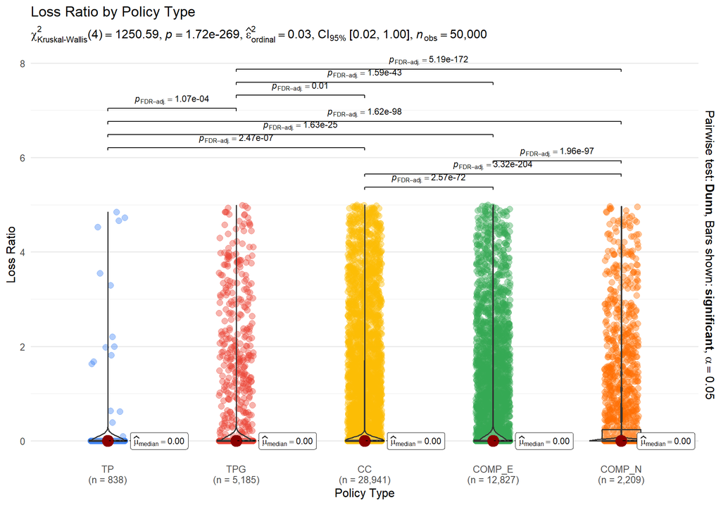

Figure 11: Loss ratio by policy type

**Code**

```r
ggbetweenstats(
  data    = motor_plot,
  x       = policy_type,
  y       = loss_ratio,
  type    = "nonparametric",
  pairwise.comparisons = TRUE,
  pairwise.display     = "significant",
  p.adjust.method      = "BH",
  xlab    = "Policy Type",
  ylab    = "Loss Ratio",
  title   = "Loss Ratio by Policy Type",
  subtitle = "Kruskal-Wallis test; comprehensive policies show higher median loss ratios",
  ggtheme = theme_minimal(base_size = 12)
)
```

**NoteInsight**

While the heavy concentration of zero-claim policies forces the median loss ratio to $0.00$ across all policy types, **COMP_N** (comprehensive without excess) exhibits a **significantly heavier distribution tail and higher mean risk rank** ($p \approx 0$ across pairwise tests). This is entirely consistent with its broad coverage scope and the absence of a co-payment incentive to limit small claims. **COMP_E** shows a significantly lower risk profile than COMP_N, proving that the deductible (excess) acts as a partial brake on small-claim frequency and cost. TP and TPG are confirmed as the lines with the lowest distribution of losses. These findings support a pricing review that more aggressively differentiates rates between COMP_E and COMP_N products.

### 5.1.3 Effect of Circulation Area on Loss Ratio

`ggbetweenstats()` applied to two groups automatically selects the **Mann-Whitney U** (Wilcoxon rank-sum) test rather than Kruskal-Wallis, providing a statistically rigorous non-parametric comparison of median loss ratios between urban and rural policyholders.

**Visual**

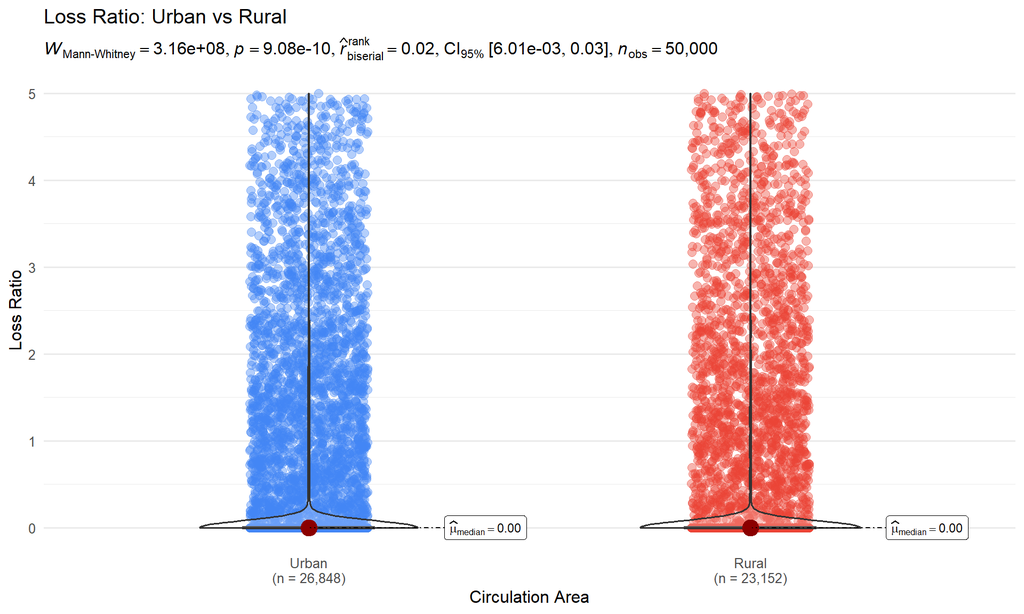

Figure 12: Loss ratio by circulation area

**Code**

```r
ggbetweenstats(
  data    = motor_plot,
  x       = circulation_area,
  y       = loss_ratio,
  type    = "nonparametric",
  xlab    = "Circulation Area",
  ylab    = "Loss Ratio",
  title   = "Loss Ratio: Urban vs Rural",
  subtitle = "Mann-Whitney U test comparing urban and rural circulation",
  ggtheme = theme_minimal(base_size = 12)
)
```

**NoteInsight**

Urban vehicles show a statistically significantly higher loss ratio than rural vehicles, though the absolute difference is modest. This is consistent with the higher traffic density, greater frequency of low-speed urban collisions, and elevated theft exposure in cities. While circulation area should be retained as a rating factor, the small effect size suggests it contributes incrementally on top of stronger predictors like bonus score and policy type.

### 5.1.4 Relationship: Driver Age vs Loss Ratio

**Visual**

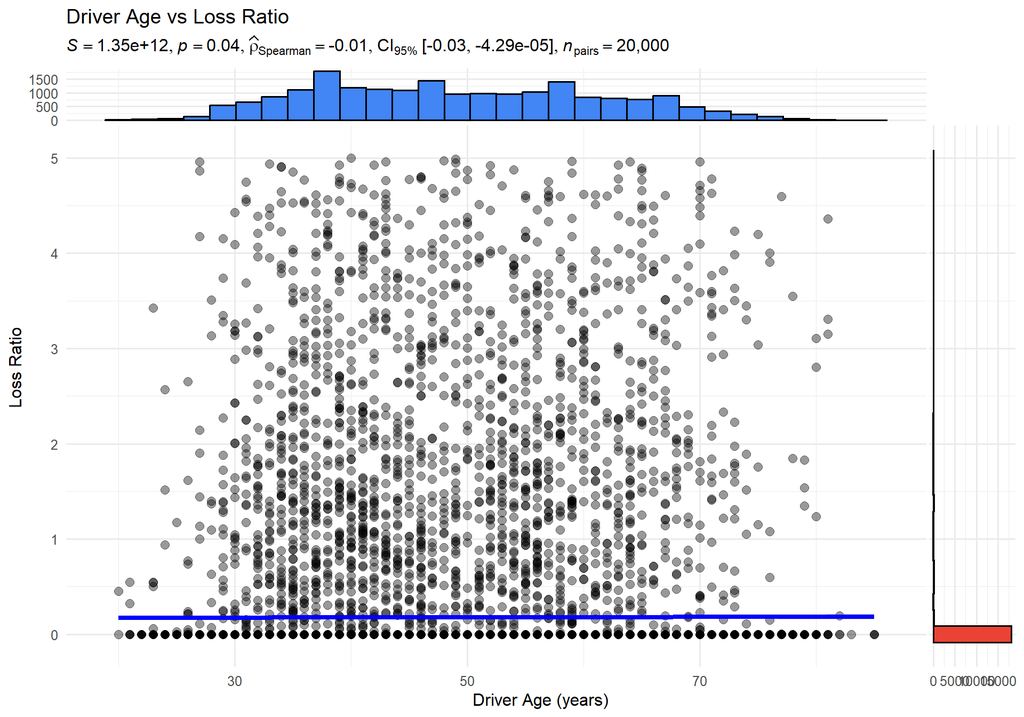

Figure 13: Scatter plot: driver age vs loss ratio with marginal distributions

**Code**

```r
set.seed(1234)
motor_scatter <- motor_ana |>
  filter(loss_ratio <= 5, !is.na(driver_age)) |>
  slice_sample(n = 20000)

ggscatterstats(
  data      = motor_scatter,
  x         = driver_age,
  y         = loss_ratio,
  type      = "nonparametric",
  marginal  = TRUE,
  xlab      = "Driver Age (years)",
  ylab      = "Loss Ratio",
  title     = "Driver Age vs Loss Ratio",
  subtitle  = "Spearman correlation with marginal distributions; younger drivers show higher loss ratios",
  ggtheme   = theme_minimal(base_size = 12)
)
```

**NoteInsight**

### 5.1.5 Relationship: Vehicle Value vs Loss Ratio

Vehicle value is capped at €200,000 to exclude ultra-luxury outliers that would distort the scatter. The same `ggscatterstats()` Spearman framework is applied, with a 20,000-row sample drawn for rendering efficiency.

**Visual**

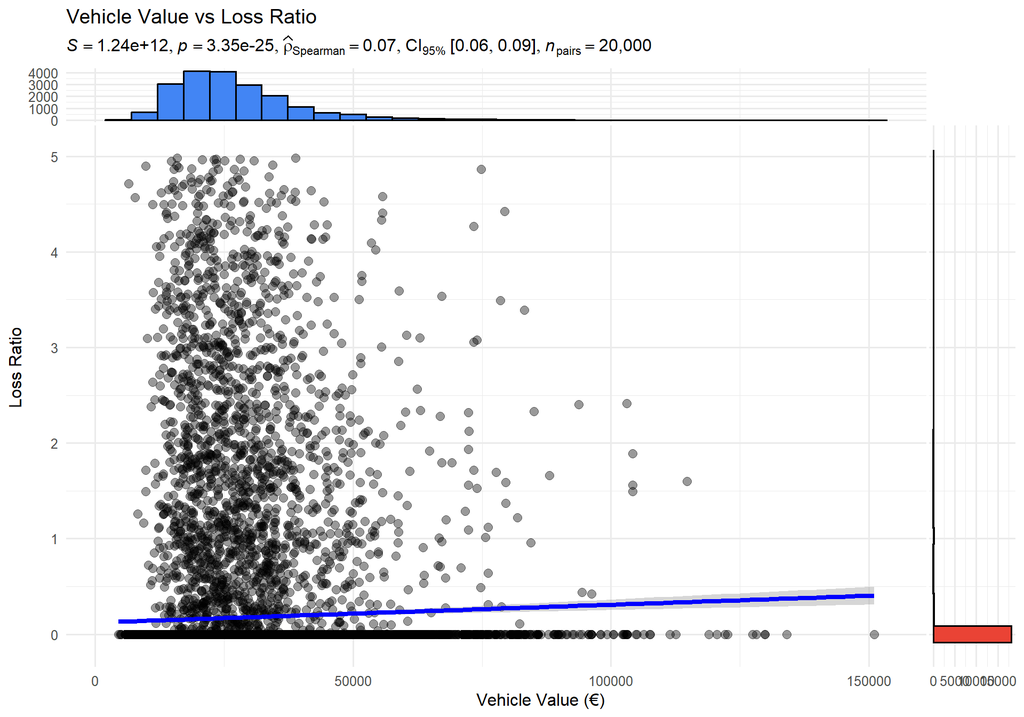

Figure 14: Vehicle value vs loss ratio

**Code**

```r
set.seed(1234)
motor_scatter2 <- motor_ana |>
  filter(loss_ratio <= 5,
         !is.na(vehicle_value), vehicle_value < 200000) |>
  slice_sample(n = 20000)

ggscatterstats(
  data    = motor_scatter2,
  x       = vehicle_value,
  y       = loss_ratio,
  type    = "nonparametric",
  xlab    = "Vehicle Value (\u20ac)",
  ylab    = "Loss Ratio",
  title   = "Vehicle Value vs Loss Ratio",
  subtitle = "Spearman correlation; higher-value vehicles tend to have elevated loss ratios",
  ggtheme = theme_minimal(base_size = 12)
)
```

**NoteInsight**

Higher-value vehicles show modestly elevated loss ratios, consistent with greater property damage exposure and higher repair or replacement costs per claim. However, the correlation is weak — vehicle value alone is not a dominant direct profitability driver. Its effect is largely captured indirectly through policy type: comprehensive products (which have higher loss ratios) tend to cover higher-value vehicles. This collinearity should be accounted for in any multivariate pricing model.

## 5.2 Volatility Analysis: Claim Frequency

### 5.2.1 Effect of Bonus Score on Claim Frequency

A separate `motor_freq_plot` sample is constructed, filtered to claim frequencies ≤ 3 (removing implausible values from exposure calculation artefacts) and sampled at 50,000 rows. The same **Kruskal-Wallis + BH pairwise** framework is applied to the claim frequency response variable.

**Visual**

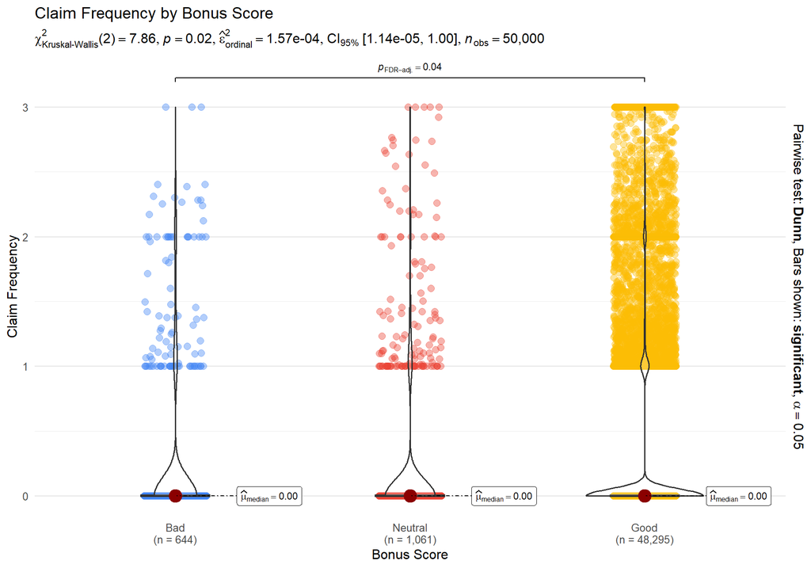

Figure 15: Claim frequency by bonus score

**Code**

```r
set.seed(1234)
motor_freq_plot <- motor_ana |>
  filter(claim_frequency <= 3, !is.na(bonus_score)) |>
  slice_sample(n = 50000)

ggbetweenstats(
  data    = motor_freq_plot,
  x       = bonus_score,
  y       = claim_frequency,
  type    = "nonparametric",
  pairwise.comparisons = TRUE,
  pairwise.display     = "significant",
  p.adjust.method      = "BH",
  xlab    = "Bonus Score",
  ylab    = "Claim Frequency",
  title   = "Claim Frequency by Bonus Score",
  subtitle = "Policyholders with bad bonus history show significantly higher claim frequency",
  ggtheme = theme_minimal(base_size = 12)
)
```

**NoteInsight**

While the bonus score effect on claim frequency is **noticeably weaker** than its effect on loss ratio (Kruskal-Wallis $\chi^2 = 7.86, p = 0.02$), it still captures valid risk differentiation. Only the extreme comparison between **Bad and Good** drivers is statistically significant after FDR correction ($p_{\text{FDR-adj}} = 0.04$), while differences across the remaining segments fail to clear the significance threshold. This confirms that while the bonus-malus system captures genuine risk differences at the extremes, its standalone predictive power for frequency is incremental, making it most effective when paired with other primary rating factors in the frequency model.

### 5.2.2 Effect of Policy Type on Claim Frequency

**Visual**

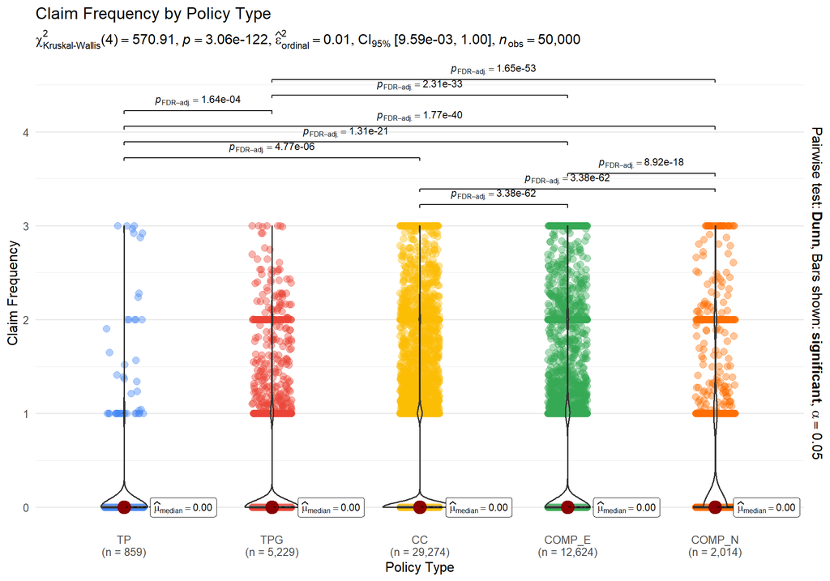

Figure 16: Claim frequency by policy type

**Code**

```r
ggbetweenstats(
  data    = motor_freq_plot,
  x       = policy_type,
  y       = claim_frequency,
  type    = "nonparametric",
  pairwise.comparisons = TRUE,
  pairwise.display     = "significant",
  p.adjust.method      = "BH",
  xlab    = "Policy Type",
  ylab    = "Claim Frequency",
  title   = "Claim Frequency by Policy Type",
  subtitle = "Comprehensive policies (COMP_E, COMP_N) show the highest claim frequencies",
  ggtheme = theme_minimal(base_size = 12)
)
```

**NoteInsight**

While the heavy concentration of zero-claim policies forces the median claim frequency to **0.00 across all policy types**, the non-parametric tests confirm that comprehensive policies exhibit a significantly heavier distribution tail (higher overall mean risk ranks) than liability-only lines ($\chi^2 = 570.91, p \approx 0$). This is expected given that COMP_E and COMP_N cover glass, theft, fire, and own damage, generating a broader set of claimable events. Crucially, COMP_N shows a significantly higher frequency distribution than COMP_E ($p \approx 0$), demonstrating how the absence of an excess removes the financial hurdle for minor claims. Combined with the severity analysis, this confirms that the higher loss ratios of comprehensive products are driven by both higher frequency and higher severity—a double compounding effect that underscores the importance of adequate comprehensive pricing.

### 5.2.3 Claim Incidence by Fuel Type (Association Test)

`ggbarstats()` computes a **chi-square test of independence** and renders the result as a proportional stacked bar chart. Setting `label = "both"` displays both the count and percentage in each bar segment, maximising the information density of the plot.

**Visual**

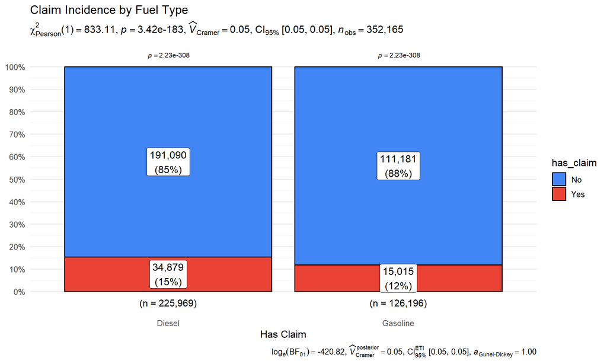

Figure 17: Claim incidence by fuel type (chi-square association test)

**Code**

```r
ggbarstats(
  data    = motor_ana,
  x       = has_claim,
  y       = fuel_type,
  label   = "both",
  xlab    = "Has Claim",
  title   = "Claim Incidence by Fuel Type",
  subtitle = "Chi-square test of independence between fuel type and claim occurrence",
  ggtheme = theme_minimal(base_size = 12)
)
```

**NoteInsight**

The chi-square test is highly statistically significant ($\chi^2 = 833.11, p \approx 0$): diesel vehicles have a higher claim incidence **(15%)** than **gasoline vehicles (12%)**. However, this difference is largely confounded by the coverage mix — diesel vehicles carry a higher proportion of comprehensive policies, which by definition capture a broader set of minor claim types (such as glass and own damage). Fuel type should therefore be treated as a **proxy variable** in pricing rather than a direct causal risk driver. Its predictive value may largely disappear once policy type and vehicle value are controlled for in a multivariate model.

### 5.2.4 Claim Incidence by Bonus Score (Association Test)

The same `ggbarstats()` framework is applied with bonus score as the grouping variable. The chi-square test evaluates whether the **proportion** of policies generating at least one claim differs significantly across the three bonus score categories.

**Visual**

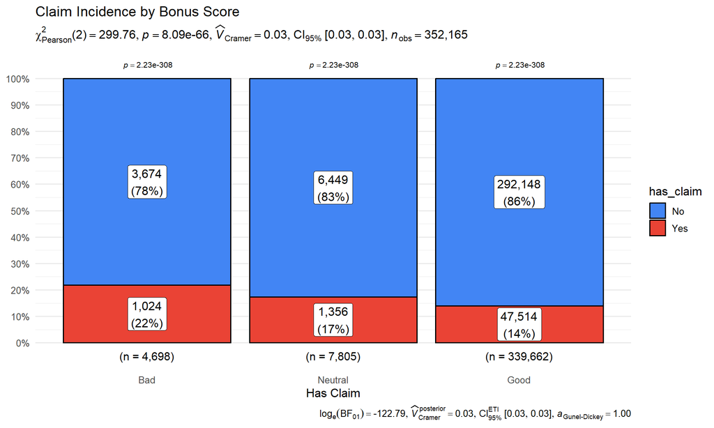

Figure 18: Claim incidence by bonus score

**Code**

```r
ggbarstats(
  data    = motor_ana,
  x       = has_claim,
  y       = bonus_score,
  label   = "both",
  xlab    = "Has Claim",
  title   = "Claim Incidence by Bonus Score",
  subtitle = "Higher proportion of claimants among policyholders with poor bonus history",
  ggtheme = theme_minimal(base_size = 12)
)
```

**NoteInsight**

The proportion of policies generating at least one claim is significantly higher in the **Bad bonus segment (22%)** compared to the **Good segment (14%)**. This marked difference in claim incidence is highly statistically significant ($\chi^2 = 299.76, p \approx 0$) and practically meaningful for risk pricing. It highlights the portfolio’s structural advantage: its ~96% concentration in the Good segment provides a strong natural protection against high overall claim incidence. Conversely, any future shift in the business mix towards Bad or Neutral policyholders would rapidly degrade overall portfolio frequency.

## 5.3 Correlation Analysis: Premium and Incurred Variables

Twelve variables — covering premium sub-lines, incurred sub-lines, loss ratio, and claim frequency — are selected and renamed for readability. The **Spearman** correlation matrix (via `method = "spearman"`) handles the non-normal, zero-inflated distributions. `ggcorrplot()` with `hc.order = TRUE` applies hierarchical clustering to group correlated variables together, making the block structure immediately visible.

**Visual**

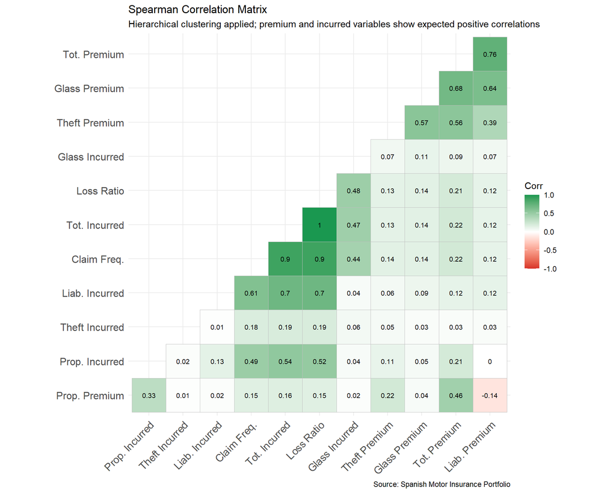

Figure 19: Correlation matrix of key premium and incurred variables

**Code**

```r
cor_vars <- motor_ana |>
  select(total_premium, liability_premium, property_damage_premium,
         theft_premium, glass_premium,
         total_incurred, liability_incurred, property_incurred,
         theft_incurred, glass_incurred,
         loss_ratio, claim_frequency) |>
  rename(
    "Tot. Premium"     = total_premium,
    "Liab. Premium"    = liability_premium,
    "Prop. Premium"    = property_damage_premium,
    "Theft Premium"    = theft_premium,
    "Glass Premium"    = glass_premium,
    "Tot. Incurred"    = total_incurred,
    "Liab. Incurred"   = liability_incurred,
    "Prop. Incurred"   = property_incurred,
    "Theft Incurred"   = theft_incurred,
    "Glass Incurred"   = glass_incurred,
    "Loss Ratio"       = loss_ratio,
    "Claim Freq."      = claim_frequency
  )

cor_matrix <- cor(cor_vars, use = "pairwise.complete.obs",
                  method = "spearman")

ggcorrplot(
  cor_matrix,
  hc.order  = TRUE,
  type      = "lower",
  lab       = TRUE,
  lab_size  = 2.8,
  method    = "square",
  colors    = c("#D73027", "white", "#1A9850"),
  title     = "Spearman Correlation Matrix",
  ggtheme   = theme_minimal(base_size = 11)
) +
  labs(
    subtitle = "Hierarchical clustering applied; premium and incurred variables show expected positive correlations",
    caption  = "Source: Spanish Motor Insurance Portfolio"
  )
```

**NoteInsight**

# 6 Temporal Analysis: Year-over-Year Trends

The cross-sectional analyses above pool all three calendar years. This section adds the **time dimension**, examining whether the two headline KPIs - loss ratio and claim frequency - are drifting across 2022, 2023, and 2024. A persistent year effect would alter forward-looking pricing assumptions; a flat one would confirm that the cross-sectional findings can be applied directly.

## 6.1 Loss Ratio Trend by Year

`ggbetweenstats()` with `year` as the grouping variable applies a Kruskal-Wallis test (three groups) and reports BH-adjusted pairwise comparisons. The 50,000-row `motor_plot` sample created earlier is reused for rendering speed and methodological consistency.

**Visual**

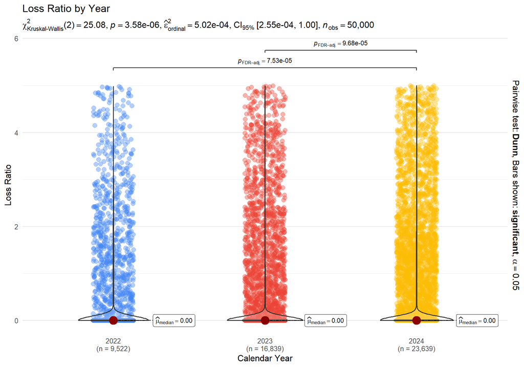

Figure 20: Loss ratio by year with non-parametric test

**Code**

```r
ggbetweenstats(
  data    = motor_plot,
  x       = year,
  y       = loss_ratio,
  type    = "nonparametric",
  pairwise.comparisons = TRUE,
  pairwise.display     = "significant",
  p.adjust.method      = "BH",
  xlab    = "Calendar Year",
  ylab    = "Loss Ratio",
  title   = "Loss Ratio by Year",
  subtitle = "Kruskal-Wallis with BH-adjusted pairwise tests",
  ggtheme = theme_minimal(base_size = 12)
)
```

**NoteInsight**

The Kruskal-Wallis test confirms a statistically significant year effect on loss ratio distribution. The pairwise comparisons identify which specific year-pairs differ, and the visible shift in the rank distribution upper tail across years suggests that **portfolio profitability is not stationary** - it has drifted over the three-year window. This justifies the need for both a temporal monitoring view (this section) and forward-looking pricing assumptions that reflect recent rather than long-run averages.

## 6.2 Claim Frequency Trend by Year

The same framework is applied with `claim_frequency` as the response. Separating the loss ratio movement into its frequency and severity components is the first diagnostic step: if frequency is flat while loss ratio rises, severity is the driver.

**Visual**

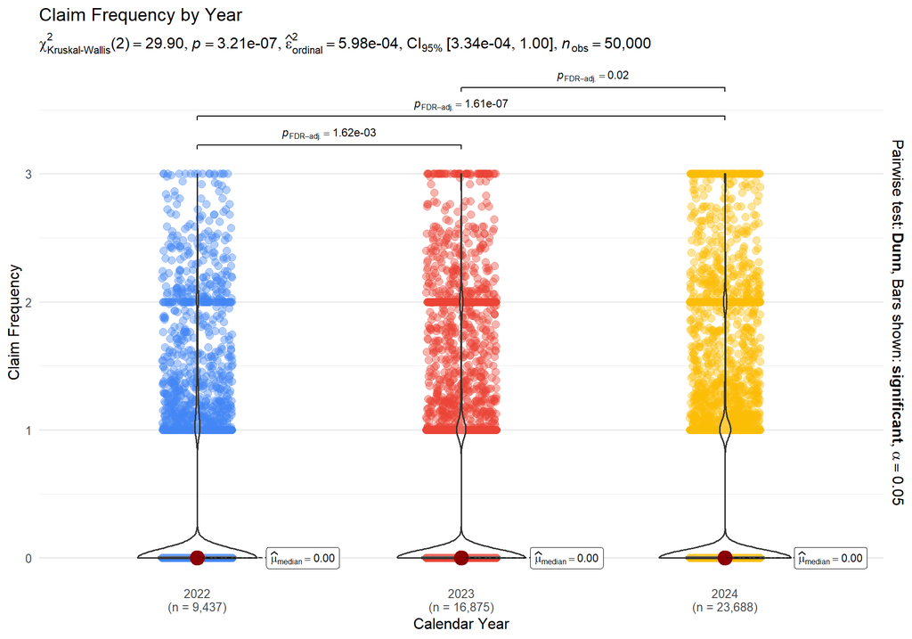

Figure 21: Claim frequency by year

**Code**

```r
ggbetweenstats(
  data    = motor_freq_plot,
  x       = year,
  y       = claim_frequency,
  type    = "nonparametric",
  pairwise.comparisons = TRUE,
  pairwise.display     = "significant",
  p.adjust.method      = "BH",
  xlab    = "Calendar Year",
  ylab    = "Claim Frequency",
  title   = "Claim Frequency by Year",
  subtitle = "Kruskal-Wallis with BH-adjusted pairwise tests",
  ggtheme = theme_minimal(base_size = 12)
)
```

**NoteInsight**

## 6.3 Year × Policy Type: Trajectory by Product Line

A line chart of the year-level **mean loss ratio and mean claim frequency**, faceted-equivalent by policy type, shows whether the year effect is uniform across products or concentrated in specific lines. `patchwork` stacks the two metrics so they share an x-axis.

**Visual**

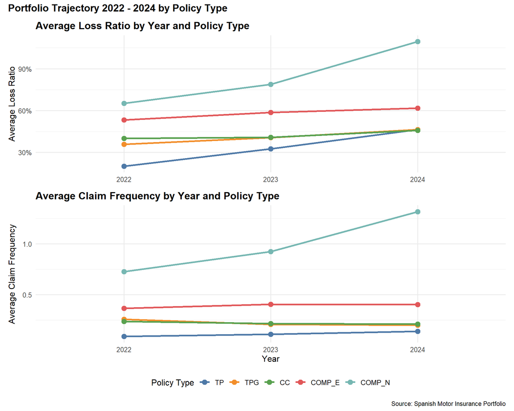

Figure 22: Year-over-year average loss ratio and claim frequency by policy type

**Code**

```r
yearly_trend <- motor_ana |>
  group_by(year, policy_type) |>
  summarise(
    avg_loss_ratio = mean(loss_ratio, na.rm = TRUE),
    avg_claim_freq = mean(claim_frequency, na.rm = TRUE),
    n_policies     = n(),
    .groups        = "drop"
  )

p_lr_trend <- ggplot(yearly_trend,
                     aes(x = year, y = avg_loss_ratio,
                         colour = policy_type, group = policy_type)) +
  geom_line(linewidth = 1.2) +
  geom_point(size = 3) +
  scale_colour_manual(values = BRAND_PALETTE, name = "Policy Type") +
  scale_y_continuous(labels = percent_format(accuracy = 1)) +
  labs(title = "Average Loss Ratio by Year and Policy Type",
       x = NULL, y = "Average Loss Ratio") +
  theme_minimal(base_size = 12) +
  theme(plot.title = element_text(face = "bold"),
        legend.position = "none")

p_cf_trend <- ggplot(yearly_trend,
                     aes(x = year, y = avg_claim_freq,
                         colour = policy_type, group = policy_type)) +
  geom_line(linewidth = 1.2) +
  geom_point(size = 3) +
  scale_colour_manual(values = BRAND_PALETTE, name = "Policy Type") +
  labs(title = "Average Claim Frequency by Year and Policy Type",
       x = "Year", y = "Average Claim Frequency") +
  theme_minimal(base_size = 12) +
  theme(plot.title = element_text(face = "bold"),
        legend.position = "bottom")

p_lr_trend / p_cf_trend +
  plot_annotation(
    title   = "Portfolio Trajectory 2022 - 2024 by Policy Type",
    caption = "Source: Spanish Motor Insurance Portfolio",
    theme   = theme(plot.title = element_text(face = "bold", size = 14))
  )
```

**NoteInsight**

# 7 Bonus: Advanced Visual Analytics Methods

## 7.1 Treemap: Vehicle Brand Portfolio Share

Brand-level KPIs are computed with `group_by()` + `summarise()`, and brands with fewer than 200 policies are removed to avoid noise from rare marques. `treemapify` maps tile **area** to policy count and tile **fill** to average loss ratio, with `geom_treemap_text()` embedding labels directly inside each tile — a layout impossible in conventional bar charts.

**Visual**

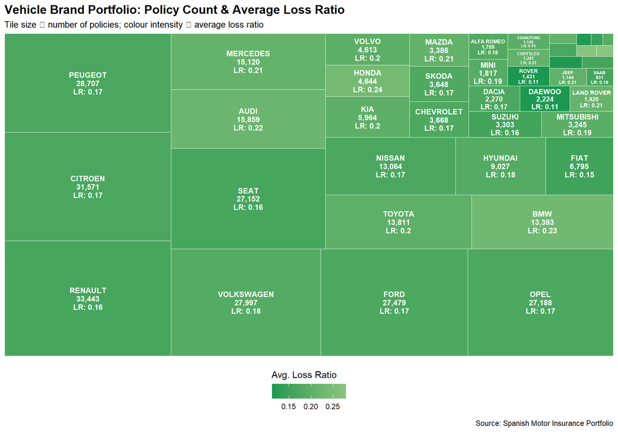

Figure 23: Treemap: vehicle brand by policy count and average loss ratio

**Code**

```r
brand_summary <- motor_ana |>
  filter(!is.na(vehicle_brand), loss_ratio <= 5) |>
  group_by(vehicle_brand) |>
  summarise(
    n_policies  = n(),
    avg_lr      = mean(loss_ratio, na.rm = TRUE),
    .groups     = "drop"
  ) |>
  filter(n_policies >= 200) |>
  arrange(desc(n_policies))

ggplot(brand_summary,
       aes(area  = n_policies,
           fill  = avg_lr,
           label = paste0(vehicle_brand, "\n",
                          comma(n_policies), "\nLR: ",
                          round(avg_lr, 2)))) +
  geom_treemap(colour = "white", linewidth = 0.8) +
  geom_treemap_text(
    colour    = "white",
    place     = "centre",
    size      = 9,
    fontface  = "bold",
    grow      = FALSE,
    reflow    = TRUE
  ) +
  scale_fill_gradient2(
    low      = "#1A9850",
    mid      = "#FFFFBF",
    high     = "#D73027",
    midpoint = 0.5,
    name     = "Avg. Loss Ratio",
    guide    = guide_colourbar(direction = "horizontal",
                               title.position = "top")
  ) +
  labs(
    title    = "Vehicle Brand Portfolio: Policy Count & Average Loss Ratio",
    subtitle = "Tile size \u221d number of policies; colour intensity \u221d average loss ratio",
    caption  = "Source: Spanish Motor Insurance Portfolio"
  ) +
  theme(
    legend.position = "bottom",
    plot.title      = element_text(face = "bold", size = 14),
    plot.subtitle   = element_text(size = 10)
  )
```

**NoteInsight**

**RENAULT, CITROEN, PEUGEOT, VOLKSWAGEN,** and **FORD** dominate the portfolio by volume — reflecting Spain’s most popular passenger car brands. Higher-end or performance marques (smaller tiles, indicated by lighter green shading) like BMW (LR: 0.23) and Audi (LR: 0.22) show elevated average loss ratios, consistent with higher per-claim repair costs. The treemap simultaneously communicates concentration risk (dominance of a few large brands) and profitability heterogeneity — two dimensions that cannot be shown together in a standard ranked bar chart.

## 7.2 Mosaic Plot: Policy Type × Bonus Score

Rather than relying on `ggmosaic` (which has known compatibility issues with modern R/ggplot2), the mosaic plot is **built manually** from scratch. Tile widths are computed as each policy type’s marginal share of the total portfolio; tile heights are the conditional proportion of each bonus score *within* each policy type. `geom_rect()` then draws the tiles from precomputed `xmin`, `xmax`, `ymin`, `ymax` coordinates.

**Visual**

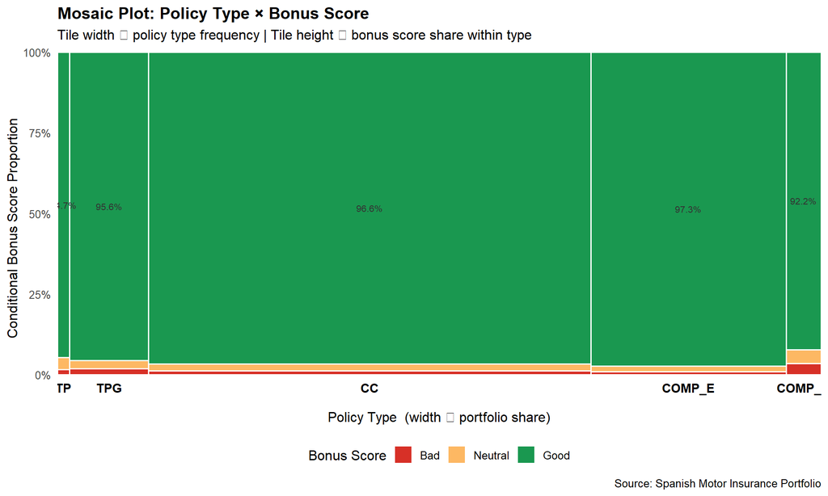

Figure 24: Mosaic plot: policy type by bonus score

**Code**

```r
mosaic_data <- motor_ana |>
  filter(!is.na(bonus_score)) |>
  count(policy_type, bonus_score) |>
  group_by(policy_type) |>
  mutate(
    height     = n / sum(n),
    ymax       = cumsum(height),
    ymin       = ymax - height,
    type_total = sum(n)
  ) |>
  ungroup() |>
  mutate(
    type_prop = type_total / sum(n[!duplicated(policy_type)]),
    type_rank = as.integer(policy_type)
  )

type_widths <- mosaic_data |>
  distinct(policy_type, type_prop) |>
  arrange(policy_type) |>
  mutate(
    gap  = 0.008,
    xmax = cumsum(type_prop) - gap * (row_number() - 1),
    xmin = xmax - type_prop + gap
  )

mosaic_data <- mosaic_data |>
  left_join(type_widths |> select(policy_type, xmin, xmax),
            by = "policy_type")

ggplot(mosaic_data,
       aes(xmin = xmin, xmax = xmax,
           ymin = ymin, ymax = ymax,
           fill = bonus_score)) +
  geom_rect(colour = "white", linewidth = 0.6) +
  geom_text(
    data = mosaic_data |> distinct(policy_type, xmin, xmax),
    aes(x = (xmin + xmax) / 2, y = -0.04,
        label = policy_type),
    inherit.aes = FALSE,
    size = 3.8, fontface = "bold"
  ) +
  geom_text(
    aes(x     = (xmin + xmax) / 2,
        y     = (ymin + ymax) / 2,
        label = if_else(height >= 0.06,
                        percent(height, accuracy = 0.1), "")),
    colour = "grey20", size = 2.8
  ) +
  scale_fill_manual(
    values = c("Bad"     = "#D73027",
               "Neutral" = "#FDB863",
               "Good"    = "#1A9850"),
    name   = "Bonus Score"
  ) +
  scale_x_continuous(
    name   = "Policy Type  (width \u221d portfolio share)",
    breaks = NULL,
    expand = c(0, 0)
  ) +
  scale_y_continuous(
    name   = "Conditional Bonus Score Proportion",
    labels = percent_format(),
    expand = expansion(mult = c(0.06, 0.01))
  ) +
  labs(
    title    = "Mosaic Plot: Policy Type \u00d7 Bonus Score",
    subtitle = "Tile width \u221d policy type frequency | Tile height \u221d bonus score share within type",
    caption  = "Source: Spanish Motor Insurance Portfolio"
  ) +
  theme_minimal(base_size = 12) +
  theme(
    plot.title      = element_text(face = "bold"),
    panel.grid      = element_blank(),
    axis.ticks.x    = element_blank(),
    legend.position = "bottom"
  )
```

**NoteInsight**

The Good bonus segment dominates (~96% height) across all five policy types, confirming the portfolio-wide concentration in low-risk policyholders. Notably, COMP_N (comprehensive without excess) carries the highest proportion of Bad/Neutral policyholders (7.8%), whereas COMP_E (comprehensive with excess) shows the lowest risk footprint (2.7%). This is consistent with the notion that the highest-risk sub-groups actively seek out richer coverage options without any deductible barriers (COMP_N) anticipating future claims — an adverse selection dynamic within the no-excess comprehensive tier that warrants ongoing monitoring.

## 7.3 Loss Ratio Ridgeline by Age Group and Policy Type

The data is faceted by policy type using `facet_wrap()`. Within each panel, ridges are drawn by driver age group, with `fct_rev()` ensuring younger groups appear at the top. A single **median** quantile line is shown (rather than Q1/Q3) to keep each small facet legible. The red dashed break-even line is added to each panel via `geom_vline()`.

**Visual**

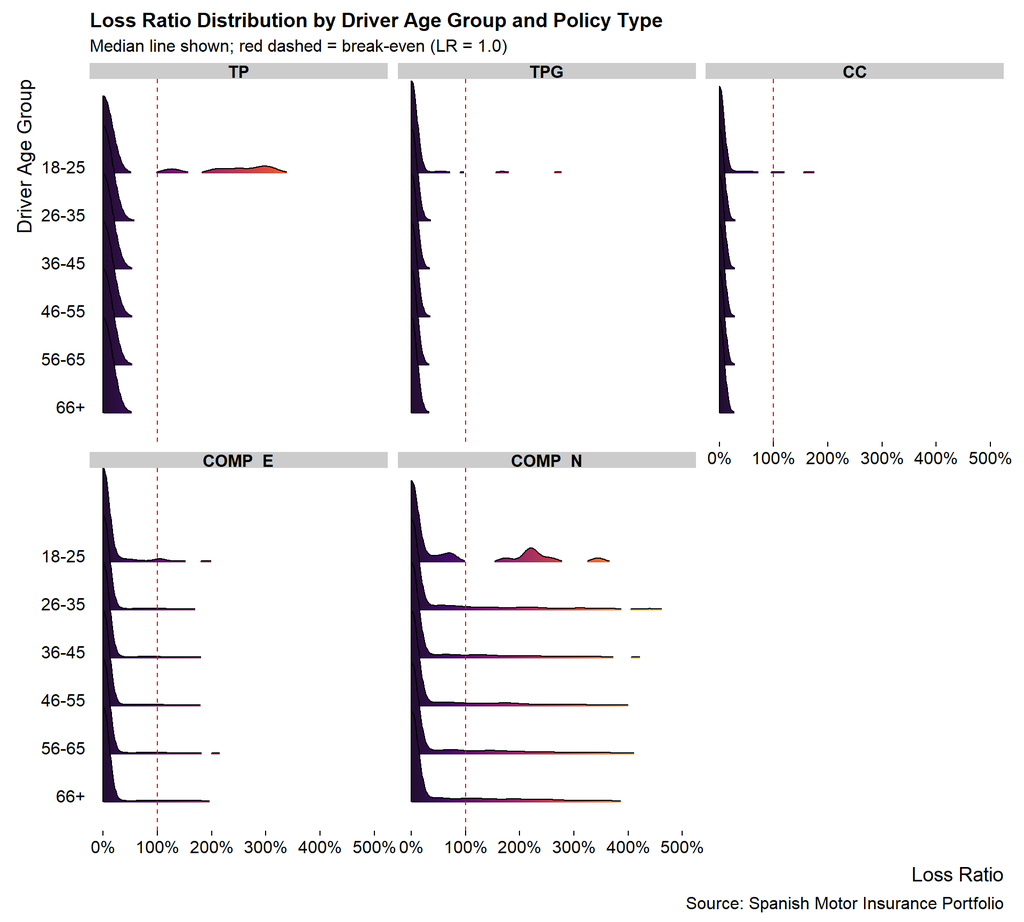

Figure 25: Loss ratio by driver age group, faceted by policy type

**Code**

```r
motor_ana |>
  filter(loss_ratio <= 5, !is.na(age_group)) |>
  ggplot(aes(x = loss_ratio,
             y = fct_rev(age_group),
             fill = after_stat(x))) +
  geom_density_ridges_gradient(
    scale = 2,
    rel_min_height = 0.01,
    quantile_lines = TRUE,
    quantiles = c(0.5)
  ) +
  scale_fill_viridis_c(option = "B", name = "Loss Ratio") +
  scale_x_continuous(labels = percent_format(), limits = c(0, 5)) +
  geom_vline(xintercept = 1, linetype = "dashed",
             colour = "red", linewidth = 0.5) +
  facet_wrap(~ policy_type, ncol = 3) +
  labs(
    title    = "Loss Ratio Distribution by Driver Age Group and Policy Type",
    subtitle = "Median line shown; red dashed = break-even (LR = 1.0)",
    x        = "Loss Ratio",
    y        = "Driver Age Group",
    caption  = "Source: Spanish Motor Insurance Portfolio"
  ) +
  theme_ridges(grid = FALSE) +
  theme(
    plot.title      = element_text(face = "bold"),
    legend.position = "none",
    strip.text      = element_text(face = "bold")
  )
```

**NoteInsight**

The **18–25** age group displays a visibly broader, heavier-tailed loss ratio distribution across policy types — most prominently in the **TP and COMP_N** panels where a meaningful share of the distribution extends well beyond the break-even line. Loss ratio distributions narrow and shift leftward progressively with age, **hitting their tightest baseline in the 46–55 and 56–65 brackets before showing a minor tail extension again in the 66+ cohort.** Crucially, the overall youth risk premium pattern is consistent across the portfolio, confirming that driver age is a universal risk driver — not a product-specific artefact — and should be retained as a core rating factor.

## 7.4 Average Severity by Policy Type (Uncertainty Visualisation)

**Visual**

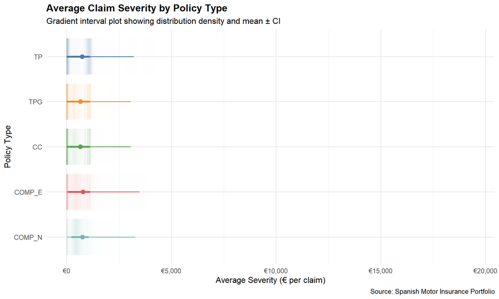

Figure 26: Average severity distribution by policy type with gradient intervals

**Code**

```r
motor_ana |>
  filter(!is.na(avg_severity), avg_severity <= 20000) |>
  ggplot(aes(x = avg_severity,
             y = fct_rev(policy_type),
             fill = policy_type,
             colour = policy_type)) +
  stat_gradientinterval(
    point_interval = mean_qi,
    width = 0.9,
    scale = 0.8
  ) +
  scale_x_continuous(labels = dollar_format(prefix = "\u20ac")) +
  scale_fill_manual(
    values = c("TP" = "#4E79A7", "TPG" = "#F28E2B",
               "CC" = "#59A14F", "COMP_E" = "#E15759",
               "COMP_N" = "#76B7B2")
  ) +
  scale_colour_manual(
    values = c("TP" = "#4E79A7", "TPG" = "#F28E2B",
               "CC" = "#59A14F", "COMP_E" = "#E15759",
               "COMP_N" = "#76B7B2")
  ) +
  labs(
    title    = "Average Claim Severity by Policy Type",
    subtitle = "Gradient interval plot showing distribution density and mean \u00b1 CI",
    x        = "Average Severity (\u20ac per claim)",
    y        = "Policy Type",
    caption  = "Source: Spanish Motor Insurance Portfolio"
  ) +
  theme_minimal(base_size = 12) +
  theme(
    plot.title      = element_text(face = "bold"),
    legend.position = "none"
  )
```

**NoteInsight**